# 9 Unsupervised Learning

## 9.6 EM algorithm

The EM algorithm is an incredibly useful tool for solving complicated maximization procedures, particularly with respect to maximizing likelihoods (typically for parameter estimation). We will describe the procedure here in the context of estimating the parameters of a two-component mixture model.

Consider the Old Faithful geyser Yellowstone National Park, Wyoming, USA with the following histogram of data on waiting times between each eruption:

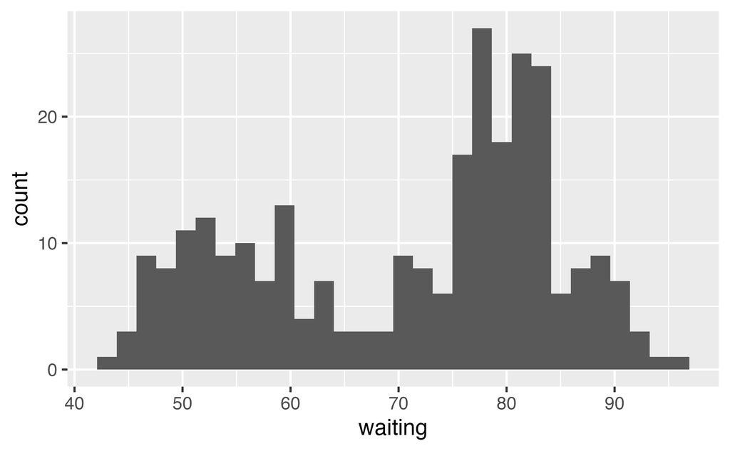

$$\begin{align}
Y_1 &\sim N(\mu_1, \sigma_1^2)\\
Y_2 &\sim N(\mu_2, \sigma_2^2)\\
Y &= (1-\Delta) Y_1 + \Delta Y_2\\
P(\Delta=1) &= \pi\\
\end{align}$$
In the simple two component case, we can see that the representation above indicates that first we generate a $\Delta \in \{0,1\}$, and then, depending on the result, we generate either $Y_1$ or $Y_2$. The likelihood associated with the above setting is:

$$\begin{align}
g_Y(y) = (1-\pi) \phi_{\theta_1}(y) + \pi \phi_{\theta_2}(y)
\end{align}$$
where $\phi_\theta$ represents the normal distribution with a vector $\theta=(\mu, \sigma)$ of parameters. Typically, in statistical theory, to find $\theta$, we would take the derivative of the log-likelihood to find the values which maximize. Here, however, the likelihood is too complicated to solve for $\theta$ in closed form.

$$\begin{align}
l(\theta; {\bf y}) = \sum_{i=1}^N \log [(1-\pi) \phi_{\theta_1}(y) + \pi \phi_{\theta_2}(y)].
\end{align}$$

If we know which point comes from which distribution, however, the maximization is straightforward in that we can use the points in group one to estimate the parameters from the first distribution, and the points in group two to estimate the parameters in the second distribution. The process of assigning points and estimating parameters can be thought of as two steps:

1. *Expectation:* an assignment (soft here, because the points are weighted) of each observation to a group.
2. *Maximization:* update the parameter estimates.

**Algorithm**: EM Algorithm for two-component Gaussian mixture. From *The Elements of Statistical Learning* (2001), by Hastie, Tibshirani, and Friedman, pg 238.

1. Take initial guesses for the parameters $\hat{\mu}_1, \hat{\sigma}_1^2, \hat{\mu}_2, \hat{\sigma}_2^2, \hat{\pi}$.
2. *Expectation Step:* compute the responsibilities:
   $$\hat{\gamma}_i = \frac{\hat{\pi} \phi_{\hat{\theta}_2} (y_i)}{(1-\hat{\pi}) \phi_{\hat{\theta}_1} (y_i) + \hat{\pi} \phi_{\hat{\theta}_2} (y_i)}, i=1, 2, \ldots, N.$$
3. *Maximization Step:* compute the weighted means and variances:
   $$\begin{align}
   \hat{\mu}_1 = \frac{\sum_{i=1}^N (1-\hat{\gamma_i})y_i}{\sum_{i=1}^N (1-\hat{\gamma_i})} && \hat{\sigma}_1^2 = \frac{\sum_{i=1}^N (1-\hat{\gamma_i})(y_i - \hat{\mu}_1)^2}{\sum_{i=1}^N (1-\hat{\gamma_i})}\\
   \hat{\mu}_2 = \frac{\sum_{i=1}^N \hat{\gamma_i}y_i}{\sum_{i=1}^N \hat{\gamma_i}} && \hat{\sigma}_2^2 = \frac{\sum_{i=1}^N \hat{\gamma_i}(y_i - \hat{\mu}_2)^2}{\sum_{i=1}^N \hat{\gamma_i}}
   \end{align}$$
   and the mixing probability $\hat{\pi} = \sum_{i=1}^N \hat{\gamma}_i / N$.
4. Iterate Steps 2. and 3. until convergence.

The algorithm shows that for a particular allocation of the points, we can maximize the given likelihood to estimate the parameter values (done in the Maximization Step). However, it is not obvious from the algorithm that the first allocation step leads to a maximization (local or global) of the likelihood. The proof of the EM algorithm converging to a local maximum likelihood (it does not necessarily converge to a global max) uses information on the marginal prior and posterior likelihoods of the parameter values and Jensen’s inequality to show that the likelihood does not decrease through the iterative steps.

Note that in the previous $k$-means algorithm we iterated between two steps of assigning points to clusters and estimating the cluster centers (we thought of the space as scaled so that the Euclidean distance was appropriate in all dimensions). Two differences in the algorithms we covered are:

1. $k$-means uses hard thresholding and EM uses soft thresholding
2. $k$-means uses a fixed standard deviation of 1, EM allows the data/algorithm to find the standard deviation

Indeed, although the EM-algorithm above is slightly different than the previous $k$-means algorithm, the two methods typically converge to the same result and are both considered to be different implementations of a $k$-means algorithm.

See the following applet for a visual representation of how the EM-algorithm converges: http://www.socr.ucla.edu/applets.dir/mixtureem.html.

## 9.7 References

[^1]: Heavily inspired by Luis Serrano’s [youtube video](https://www.youtube.com/watch?v=BaM1uiCpj_E). Also note his other [educational materials](https://serrano.academy/)